# Tugas Pertemuan 5

Fatih Avicenna Hizir

2025-10-02

## Library

```r
library(TSA)
library(TTR)
library(MASS)
library(aTSA)
```

```r
library(readxl)
library(ggplot2)
library(tsibble)
library(tseries)
library(forecast)
library(graphics)
```

## Import Data

```r
data_tsla <- read_excel("~/Downloads/TSLA_weekly.xlsx", sheet = "Weekly Data")
data_tsla <- data_tsla[, c("Date", "Close")]

head(data_tsla)
```

```
## # A tibble: 6 × 2
##   Date                Close
##   <dttm>              <dbl>
## 1 2018-01-29 00:00:00  22.9
## 2 2018-02-05 00:00:00  20.7
## 3 2018-02-12 00:00:00  22.4
## 4 2018-02-19 00:00:00  23.5
## 5 2018-02-26 00:00:00  22.3
## 6 2018-03-05 00:00:00  21.8
```

```r
str(data_tsla)
```

```
## tibble [198 × 2] (S3: tbl_df/tbl/data.frame)
##  $ Date : POSIXct[1:198], format: "2018-01-29" "2018-02-05" ...
##  $ Close: num [1:198] 22.9 20.7 22.4 23.5 22.3 ...
```

```r
dim(data_tsla)
```

```
## [1] 198   2
```

```r
data_tsla.ts<-ts(data_tsla$Close)
summary(data_tsla.ts)
```

```
##    Min. 1st Qu.  Median    Mean 3rd Qu.    Max.
##   12.34   19.84   27.77   92.01  194.85  407.36
```

```r
#Partisi Data
#Rata-Rata
meants <- mean(data_tsla.ts)
#Varians/Ragam
varts <- var(data_tsla.ts)
dttrain <- data_tsla.ts[2:150]
dttest <-  data_tsla.ts[151-199]
train.ts <- ts(dttrain)
test.ts <- ts(dttest)
```

## Cek Stationer dalam Rataan dan Ragam

#### Plot Time Series

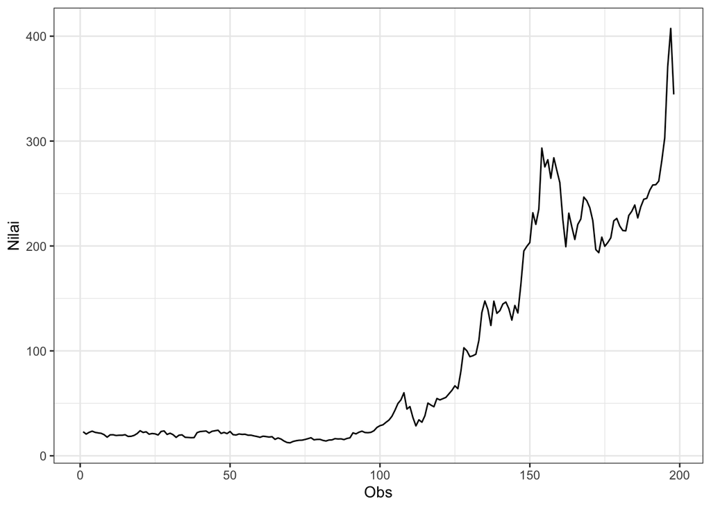

```r
plot_stas <- data_tsla.ts  |> as_tsibble() |>
  ggplot(aes(x = index, y = value)) + geom_line() + theme_bw() +
  xlab("Obs") + ylab("Nilai")
plot_stas
```

Plot deret waktu tersebut memperlihatkan bahwa data tidak bersifat stasioner pada rataan, yang tampak dari adanya pola tren yang berfluktuasi. Selain itu, data juga tidak stasioner dalam ragam, ditunjukkan oleh perbedaan lebar pita dari waktu ke waktu.

#### Plot ACF

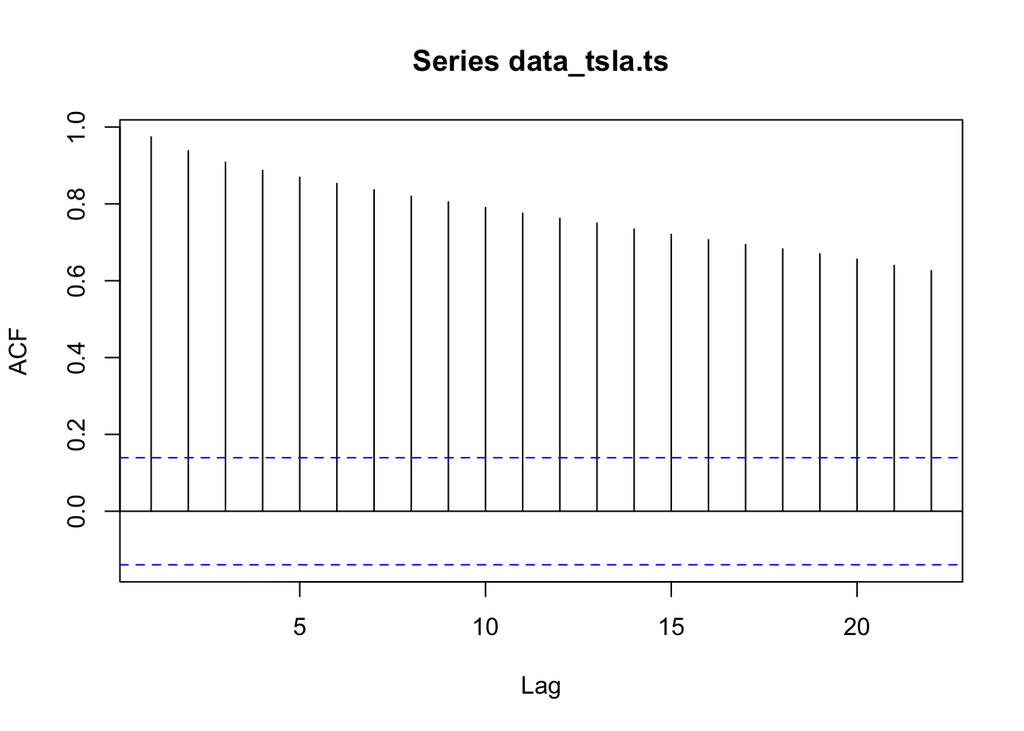

```r
acf(data_tsla.ts)
```

Jika ditinjau dari pola ACF, tampak bahwa autokorelasi mengalami penurunan secara lambat (Tail Off), sehingga dapat disimpulkan bahwa data belum mencapai kestasioneran pada rataannya.

#### Uji ADF

```r
tseries::adf.test(data_tsla.ts)
```

```
##
##  Augmented Dickey-Fuller Test
##
## data:  data_tsla.ts
## Dickey-Fuller = -1.2285, Lag order = 5, p-value = 0.8991
## alternative hypothesis: stationary
```

𝐻0 : Data tidak stasioner dalam rataan

𝐻1 : Data stasioner dalam rataan Hasil uji ADF menunjukkan nilai p sebesar 0.8991, yang melebihi taraf signifikansi 5%, sehingga keputusan yang diambil adalah gagal menolak 𝐻0 . Dengan demikian, data dapat dikatakan tidak stasioner pada rataan, sejalan dengan temuan dari plot deret waktu maupun plot ACF.

#### Plot Box Cox

```r
indeks <- seq(2:199)
bc = boxcox(data_tsla.ts~indeks, lambda = seq(-6,4,by=0.01), data=data_tsla.ts)
```

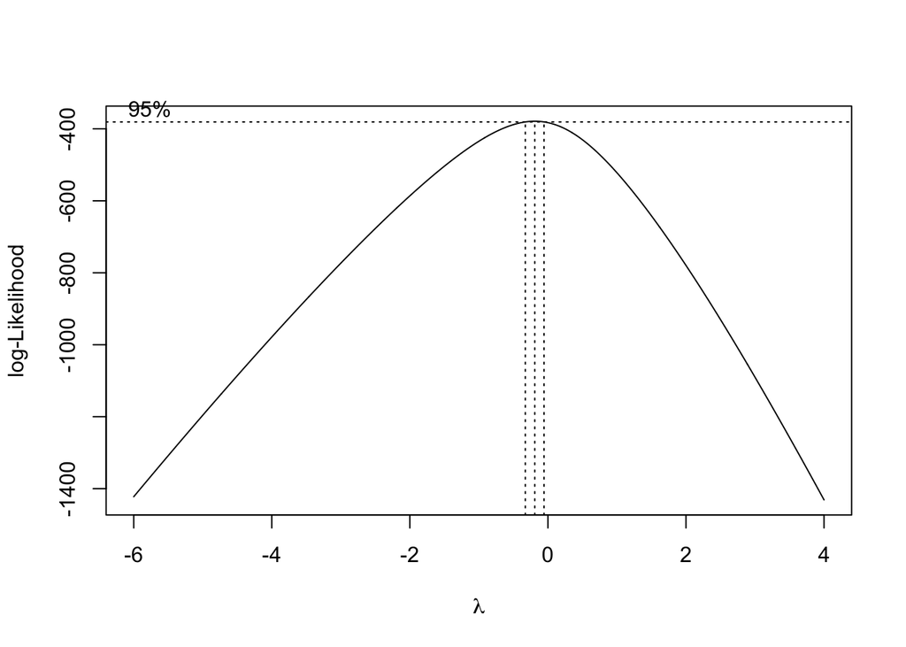

```r
# Nilai lambda optimum
lambda <- bc$x[which.max(bc$y)]
lambda
```

```
## [1] -0.19
```

```r
# Selang kepercayaan 95% untuk lambda
ci_lambda <- bc$x[bc$y > max(bc$y) - 0.5 * qchisq(0.95, 1)]

# Batas bawah dan batas atas
ci_lower <- min(ci_lambda)
ci_upper <- max(ci_lambda)

c(Batas_Bawah = ci_lower, Batas_Atas = ci_upper)
```

```
## Batas_Bawah  Batas_Atas
##       -0.32       -0.06
```

- Nilai optimum 𝜆 = **-0.19**
- CI 95% = **[-0.32, -0.06]**
- Karena seluruh selang berada jauh dari 1, maka dapat disimpulkan bahwa **data tidak stasioner dalam ragam**, sehingga transformasi Box–Cox memang diperlukan untuk menstabilkan varians.